# Inspector manual

# Index

1. Introduction
2. Features
3. Using Inspector
   - Project
   - Radio network
   - Receiving antennas stack
   - Automatic mode
   - Performing measurements
     - Collecting measurement data
     - Saving measurement
     - Additional data
     - Using and managing saved measurements
   - Custom information configuration
4. Appendix
   - Radio network configuration file format
   - Antenna characteristics file format
   - Report template
   - 3rd party software licence

# Introduction

Inspector is intended for making static measurements of radio network parameters in the field. It is designed to reduce the time and the possibility of mistakes during measurement operations. The stored data is ready for further analyses and reports.

# Features

- Collecting measurements into separated projects
- Containing radio network configuration
- Displaying quasi echo pattern for SFN
- Containing frequency characteristics of measuring antennas (antenna factor)
- Additional custom information for each measurement
- Automatic antenna positioning
- Automatic instrument (R&S ETL) configuring and reading measurements
- Generating measurement report
- Custom measurement report design
- Exporting measurements to GoogleEarth

# Using Inspector

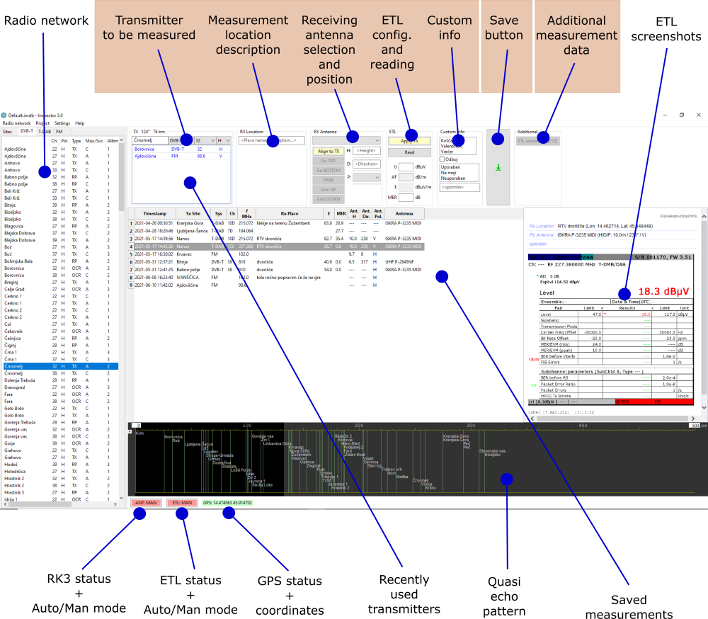

user interface

## Project

A Project represents a set of measurements. The available project operations are:

- create new project
- select existing project
- delete existing project
- export backup (zip)
- import backup

This opeartions can be accessed from the Project menu.

## Radio network

This is the collection of transmitters and realtions between them. It contains information about their geographic locations and the signal propagation dependencies.

It has two purposes:

- It acts as a quick selection list of **known** transmitters.
- The application generates a quasi echo pattern at the receiving location. Just the time axis is relevant, since it is unaware of signal levels.

In the radio network configuration data, every site and transmitter has its unique ID. Inspector preserves this IDs also in saved measurements. If radio network data is collected from an existing databse, the measurements can be easily linked with data in the original network database.

The Radio network configuration can be imported by JSON or CSV file. It is also possible to export a JSON file. The configuration can be also updated from a web server if available at a specified URL (general setting).

## Receiving antennas stack

Inspector includes the receiving antennas data. For every single antenna it holds the following information:

- antenna name
- frequency characteristics (antenna factor)
- physical connnecton to the KR3

Every antenna can have defined a single characteristic or two separate characteristics for polarization H and V.

## Automatic mode

After a transmitter has been selected for measurement (from the *Radio network list* or from the *Recently used Tx list*), receiving antenna has to be aligned to the transmitter (by direction and polarization) and ETL has to be configured according to transmitters parameters. This two tasks can be done manually or automatically just after the transmitter has been selected.

- Automatic mode for antenna is switched by the ANT status button in the status bar or by [F1] key.
- Automatic mode for ETL is switched by the ETL status button in the status bar or by [F2] key.

When ETL is in automatic mode, the configuration and reading procedures are done automatically. When both, antenna and ETL, are in automatic mode, Inspector waits antenna to reach its final position before reading ETL results.

## Performing and using measurements

### Collecting measurement data

Every single measurement collects the following set of information:

#### Trasmitter being measured (Tx-actual)

- Site name
- System (DVB-T, T-DAB, FM, ...)
- Channel/Frequency
- Polarization

**NOTE:** When transmitter site name is entered (typed) manually, it is considered an **unknown site**. It means that the coordinates of that site are unknown and there is no relation to the original database.

**NOTE:** Only the transmitter selected from the 'Radio network' list is considered a **known transmitter**. It is related to the original database. When any transmitter parameter (System, Channel, Frequency) is set manually, that transmitter is considered **unknown**. It has no relation to the original database.

Below the Tx-actual fields, there is a list of **recently used** trasmitters. It is just for the convenience of operator, since the Tx-actual can be selected also from this list. Any Tx from this list can be removed by selecting it and pressing the [Delete] key on keyboard.

#### Location of reception (Rx place)

The location of measurement is determined by coordinates, provided by GPS. Every location can/should have a name or description (Rx place name).

#### Receiving antenna (Rx antenna)

When an antenna is selectd from dropdown list, it is automatically connected to **RK3 output**. At the same time the **antenna factor** is determined, regarding the Tx frequency.

Antenna can be positioned manually to the wanted height, direction and polarization by entering the value into corresponding fields.

Antenna can be aligned with the selected transmitter (by direction and polarization). The [Align to Tx] button is used for manual alignment. Automatic mode is aslo available.

#### Measuring quantities (ETL instrument)

Before reading measurements, ETL has to be configured to the transmitters radio system. In automatic mode, the configuration starts after Tx is selected or any parameter (system, channel, frequency) is changed. After configuration is completed, the measurements are read from ETL. For manual operation, the button [Apply Tx] for configuration and [Read] for reding, are also available at any time.

#### Custom information

Every measurement can contain any additional custom information, entered by operator.

### Saving measurement

When all above measurement parameters are ready, everything can be saved by clicking the "Save" button.

### Additional data

After a new measurement had been saved, additional screenshots from ETL instrument can be appended.

**NOTE:** The additional information can be attached only to the last saved measurement.

### Using and managing saved measurements

#### Delete measurements

Select measurements (rows in the table) > mouse right click > menu > Delete

#### Remove attached image from selected measurement

Select a single measurement (row in table) > drag the image out from the right pane

#### Copy measurements to clipboard as text

Select measurements (rows in the table) > press [CTRL+C]

#### Export measurements to Report

Select measurements (rows in the table) > mouse right click > menu > Report

**NOTE:** The report style and layout can be customized.

#### Export measurements to Google Earth KMZ file

Select measurements (rows in the table) > mouse right click > menu > KMZ

## Custom information configuration

Beside the predefined measurement data, Inspector provides possibility to add custom information to each measurement. In oreder to use this feature, some configuration is needed. The configuration can be entered in textual scripting form using a dialog: *Settings > Custom info*.

Every custom input control is defined by the following parameters:

- input control type (list, pull-down list, combo box, check box, text filed)
- Name (parameter name)
- Opt (a set of choices, availabe to the operator)
- flags

**input control type**

- `CHECK` (checbox)
- `PULLDOWN`
- `COMBO` (same as PULLDOWN with optional text field)
- `LIST_SINGLE_SELECT` (list of choices, where only a single option can be selected)
- `LIST_MULTI_SELECT` (list of choices, where multiple options can be selected)
- `TEXT_SINGLE_LINE` (no predefined choices; user can enter any value)

**Name**

`Name` is considered a custom info name representing a group of selected choices. Multiple input controls may have same `Name`. Their values will be grouped together under the same `Name`. The `Name` may be empty string `Name=""`. `Name` may contain alphanumeric characters and underscore. The first character must be a letter.

**Opt**

A set of availabe choices (values) in the input control.

**flags**

- `F_DISCARD_EMPTY`

If this flag is set, the prameter will not be saved with measurement when no choice was selected. (By default, empty value is saved if no choice was selected.)

- `F_PERSISTENT_VALUE`

After saving a measurement, all custom info controls are reset by default. If this flag is set, the selection will remain unchanged.

**Examples:**

`CHECK, Name="Line_of_sight"`

`CHECK, Name="", Opt={"Line of sight"}`

`LIST_MULTI_SELECT, Name="weather", Opt={"rain","wind","cloudy","cold"}, F_PERSISTENT_VALUE, F_DISCARD_EMPTY`

`TEXT_SINGLE_LINE, Name="remark", F_DISCARD_EMPTY`

# Appendix

## Radio network configuration file format

Inspector supports two file formats for radio network configuration: **JSON** and **CSV**. Configuration file contains data for both; transmitters and transmitter sites. It must be **UTF-8** encoded.

**Data fields for Site:**

```
id   <unsigned integer> (mandatory) unique identifier of the Site
name <string>           (mandatory)
lon  <float>            (mandatory) longitude part of geographic coordinate
lat  <float>            (mandatory) latitude part of geographic coordinate
```

**Data fields for Transmitter:**

```
id           <unsigned integer> (mandatory) unique identifier of the Tx
site_id      <unsigned integer> (mandatory) unique identifier of the Site which Tx belongs to
system       <string>           ["DVB-T" | "DVB-T2" | "T-DAB" | "FM"]
ch           <string>           channel ["38" | "12C" | ...]
fr           <float>            Frequency in MHz. Needed only for FM transmitters.
pol          <string>,          ["h" | "v"]
parent_tx_id <unsigned integer> predecessor Tx in SFN chain  (0 = No parent -> primary TX)
idelay       <unsigned integer> SFN: internal delay in microseconds
mux          <string>           (optional) multiplex
allotment    <string>           (optional)
service      <string>           FM radio program name
sfn_cell_id  <string>           SFN group. Needs to be defined only for 'primary Tx' (parent_tx_id==0)
```

**CSV format:**

```
id;name;lon;lat;                                                                       (Sites section header)
...values...
...values...
...values...
id;site_id;system;parent_tx_id;pol;ch;fr;idelay;mux;allotment;service;sfn_cell_id;     (Tx section header)
...values...
...values...
...values...
```

The fields (columns) may be arranged in any order.

**JSON format:** (default)

```javascript
{
    "site": [       (list of all sites)
        {
            "id":   <unsigned integer>,
            "name": <string>,
            "lon":  <float>,
            "lat":  <float>
        },

        ...

    ],
    "tx": [                 (list of all transmitters)
        {
            "id":           <unsigned integer>,
            "site_id":      <unsigned integer>,
            "system":       <string>,
            "ch":           <string>,
            "fr":           <float>,
            "pol":          <string>,
            "parent_tx_id": <unsigned integer>,
            "idelay":       <unsigned integer>,
            "mux":          <string>,
            "allotment":    <string>,
            "service":      <string>,
            "sfn_cell_id":  <string>
        },

        ...
    ]
}
```

## Antenna characteristics file format

All data for antennas are held in a single CSV file. The file format is:

```
                                    ### FIRST FORM ###
ANTENNA;ISKRA P-3235 MIDI;extra     Antenna header; start with "ANTENNA". The second field is antenna name.
FREQ;AF                             Charact. header (undefined polarization; same chracteristics for H and V)
174.930;6.8                         Charact. point data
...
...
                                    ### SECOND FORM ###
ANTENNA;STMM SL88-108FM;extra
FREQ;AF_V;AF_H                      V and H polarizations
87.500;0;0.6
...
...
                                    ### THIRD FORM ###
ANTENNA;SOME_OTHER;extra
FREQ;AF_V                           V polarization
87.500;0
...
...
FREQ;AF_H                           H polarization
87.500;0.6
...
...
```

**Antenna header** may contain the third field as `extra` data. Currently it accepts a series of RK3 commands to switch seleted antenna to the RK3 output.

Example for the `extra` field: `RK3_CMD[K11,K21]`

## Report template

Reports are generated in **HTML** file format. The final HTML is based on a single **template** HTML file. Template is separated into two sections; DOC and SNAP. DOC represents entire document, SNAP represents a single measurement. The corresponding data insertion is done by using the placeholders in form of `{{data.key.to.be.inserted}}`

General form of template is:

```html
<!--DOC-->
<html>
    <head>
        <meta http-equiv=content-type content="text/html; charset=UTF-8">
    </head>
    <body>
        {{snap[]}}
    </body>
</html>
<!--/DOC-->

<!--SNAP-->
<div class="snap">

    <!-- the content of a single measurement -->

</div>
<!--/SNAP-->
```

The current template in use resides at `C:\\ProgramData\Rfpeek\Report\report.template.html` If missing, Inspector creates a default one.

The available placeholders are:

```
{{project.filename}}
{{snap.timestamp}}           Timestamp
{{snap.rx.place}}            Place name/description of the measurement location
{{snap.rx.lon}}              Longitude of the measurement location (GPS)
{{snap.rx.lat}}              Latitude of the measurement location (GPS)
{{snap.ant.type}}            Receivicng antenna type
{{snap.ant.height}}          Receivicng antenna height
{{snap.ant.dir}}             Receivicng antenna direction
{{snap.ant.pol}}             Receivicng antenna polarization
{{snap.tx.site.name}}        Transmitter site name
{{snap.tx.sys}}              Transmitter system (DVB-T, T-DAB, FM, ...)
{{snap.tx.ch}}               Transmitter channel
{{snap.tx.fr}}               Transmitter frequency
{{snap.mres.fs}}             Measured quantity: fieldstrength [dBuV/m]
{{snap.mres.mer}}            Measured quantity: MER - Modulation Error Ratio
{{snap.custom.CI-NAME}}      A specific CustomInfo parameters Name, e.g. {{snap.custom.remark}}
{{snap.custom.*}}            All CustomInfo parameters
{{snap.image[]}}             All attached images
{{snap[]}}                   All 'snap' sections
```

## 3rd party software licence

Inspector is using the 7-zip program which is licensed under the GNU LGPL license. www.7-zip.org